# Draft Facebook API Report

# **MiniProject 2**:

## Code:

### Gathering RawData:

```r
    website_URL = "https://www.facebook.com/thousandamazingplacesonearth/"

    website_Id = FbObjectId(website_URL, token)

    #Making the query. I first tested this out on the Graph API Explorer
    ## Note: The limit for number of posts
    query= paste("https://graph.facebook.com",website_Id, "?fields=posts.limit(100){place}",sep="/")

    #Pulling RawData
    raw_Data= callAPI(query,token)


    #Formatting the raw Data:
    ## I looked at the returned format again at the graph API explorer.
```

### Planning:

#### Query Response Structure:

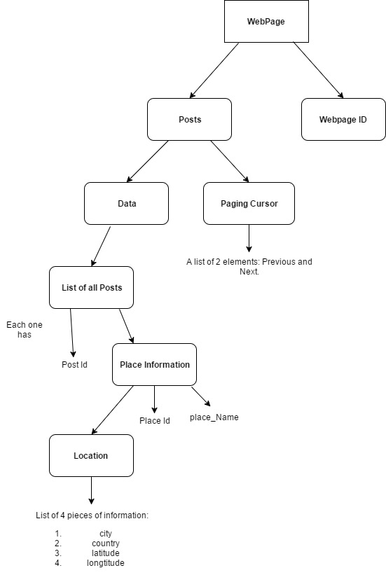

#### Paging Response Structure:

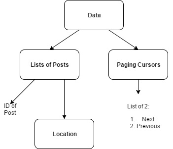

#### Desired Organized Output Structure:

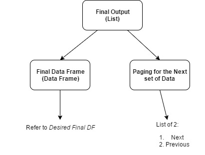

#### Desired Final DF:

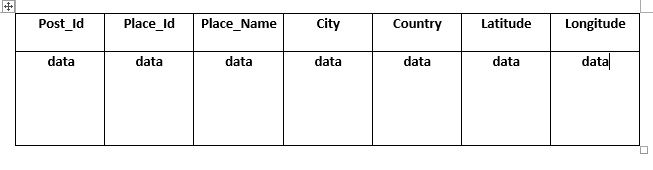

### Pesudocode For Parsing:

__NOTE: This process is based on similar procedure as the source code of the Rfacebook Package. I do not take credit for the idea behind this parsing. I merely studied the structure of the Rfacebook source code and tried to adapts some parts of it. The functions that I studied are the [getPage](https://github.com/pablobarbera/Rfacebook/blob/master/Rfacebook/R/getPage.R) function, the *pageToDF & UnlistWithNA* functions under the [Utils.R package](https://github.com/pablobarbera/Rfacebook/blob/master/Rfacebook/R/utils.R)

I strongly recommand to use the function *UnlistWithNA*(unavailable for direct access under the Rfacebook Package) under the [Utils.R package](https://github.com/pablobarbera/Rfacebook/blob/master/Rfacebook/R/utils.R) for parsing of queries not supported by the methods of the Rfacebook. *UnlistWithNa* function includes pre-made parsing function for many possible fields. Furthermore, the general structure of this function can be adapted to parse JSON formatted information.__

1: Navigate to the *data* section of the *roughData*, through format like: `rough_Data$posts$data`.

2: At the *data* section, the underlying strcture is a list of elements. Each element containing it’s own list of information. + In order to subset the list, the general structure of `list[element][[field_Lvl_1]][[field_Lvl_2]]`. for example. The *place* field has a nested field of *location*. To extract it from the *data* section. Something like: `data[[1]][["place"]][["location"]]` can be used. + The general format can be applied to multiple levels of nesting if the data is organized correctly.

3: Since some of the *posts* won’t have *location* (or other fields), when trying to access them, a *NULL* element will be the response. It will be needed to be replaced with *NA*. The end result is a list where each element corresponds to the post information.

4: By going through step 2 & 3 for all the desired fields (note they should all be the same length), should be in their own lists. Then a data frame can be merged from these lists. **The key is that the fields to be coerced into a data frame all need to be the same length. Which is one of the main diffculties for coming up with an automated program to format data frames.**

5: The *paging* URLs are already in the correct query format and just need to be extracted using *callAPI* function. Repeat steps 1 to 4 for the data that is pointed to by the *paging* information.

6: Finally merge all the data frames of the initial query and the subsequent paging matrix can be merged into one big matrix to be the final output.